# 라그랑주 승수법

- 가정 : 목적함수의 Min/Max를 구하는 문제에서 제약조건이 있을 때, 목적함수의 Min/Max를 달성하는 해는 해당 해의 목적함수와 제약함수에서의 극값이 같은 해일 것이다. 만약 이를 달성하는 해가 여러개 있다면 이를 직접 목적함수에 대입해서 최적해를 찾아야 함
  - 조건1: 목적함수가 이차식 이상이어서 극값이 존재해야 함
  - 조건2: 제약식이 목적함수의 변수 수를 넘지 않아야 함(둘이 만나지 못할 수도 있음)
  - 조건3 제약조건의 gradient vector가 해당 값에서 미분 가능해야 함(gradient vecotr가 0벡터가 아니어야 함)
- 공식 : 두 함수 식의 gradient 가 같은 방향이어야 하기 때문에 실수배(방향은 같지만 크기는 다를 수 있기 때문)
- 일반화 공식 : L의 gradient vector가 0벡터인 지점 = 최적해

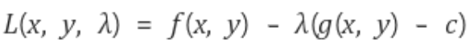

- 제약조건이 여러개일 때 : 어떤 해의 목적함수의 gradient vector가 어떤 해의 각 제약조건에서의 gradient로 이루어지는 평면/입체면안에 있을 때 해당 해가 최적해일 것이다.

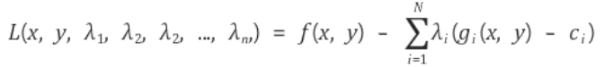

# 쌍대문제

- 최적화 문제를 원초문제와 쌍대문제의 두 가지 관점에서 바라볼 수 있음
- 예를들어 최적해 (x,y)를 찾는 과정을 (z)를 찾는 과정으로 바꾸어서 사용할 수 있음
- 쌍대문제의 상한은 원문제의 하한 https://ratsgo.github.io/convex%20optimization/2018/01/25/duality/

# 라그랑주 승수법과 쌍대문제

- 쌍대문제에서 곱한 미지수가 라그랑주의 gradient 상수배 값이 됨.
- 순서 :
  - 라그랑주 승수법을 통해서 L의 최솟값을 구함.
  - 이 과정에서 W, b에 대한 제약식, gradient 상수배 변수가 양수라는 제약식이 생길 것임.
  - 이러한 argmin(L) 방정식을 구했다면, 이것은 목적함수와 같거나 작음.(목적함수의 하한)
    - argmin(L) <= 목적함수의 값
  - argmin(L)이 위로 볼록함수, 목적함수가 아래로 볼록함수이기 때문에 argmin(L)을 max로 만드는 값이 목적함수를 min으로 만드는 값
  - 해당 계산을 통해 최적해, gradient 상수배를 구함